fossil

# epiForest, dug back up.

27 results: 2 exact, 3 agree, 2 partly agree, 7 differ, 13 not attempted; 6 verdicts set by a reviewer. epiForest was lost; it was rebuilt from the paper as an R package, and the paper's simulation study of 2,400 data sets was run again.

See every result

## Install epiforest

R package

```
remotes::install_github("jeonglab-bcm/fossil/PMC2648748/package")
```

R 4.1 or later with randomForest 4.7 or later. Tested with R 4.3.3 and randomForest 4.7-1.1.

[README](https://github.com/jeonglab-bcm/fossil/blob/main/PMC2648748/package/README.md) [Tutorial](https://github.com/jeonglab-bcm/fossil/blob/main/PMC2648748/package/tutorial/TUTORIAL.md)

## Fig. 2

Fig. 2. Power of epiForest, BEAM, stepwise logistic regression and the chi-squared test: the share of 100 simulated data sets in which both disease loci are found at 0.05 after Bonferroni, for three disease models, four MAFs and r² 0.7 and 1.0. We did not run BEAM; its bars are left empty in our run.

Differson review

Published

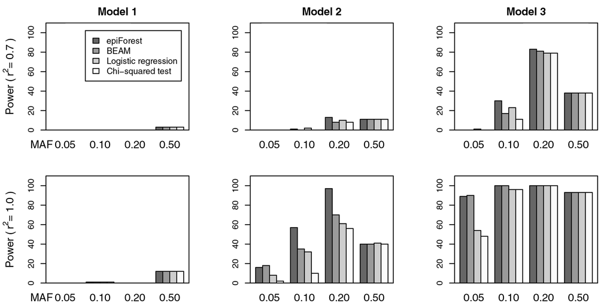

Our run

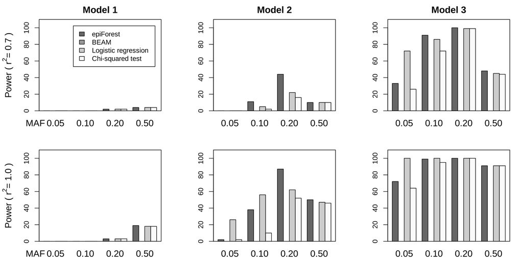

**Fig. 2, the figure (pixels, BEAM bars masked)**

68.6% within 2 px, Differs

**Fig. 2, power of the chi-squared test (24 bars)**

20 of 24 values, Differs

**Fig. 2, power of epiForest (24 bars)**

15 of 24 values, Differs

**Fig. 2, power of stepwise logistic regression (24 bars)**

17 of 24 values, Differs

The pixel score (68.6% of our ink near the paper's) is no better than our own bars shifted by 5 power points (71.5%), a shift within Monte Carlo error, so the drawing cannot settle the comparison; the bar values do (fig2.epiforest, fig2.lr, fig2.chisq). Both wrong-input controls score lower (22.6%, 49.1%). 20 of 24 bars within Monte Carlo error; all four misses are model 3 at small MAF, where our chi-squared power is higher than the paper's (r2 = 0.7: 26, 72, 99 against 0, 11, 79 at MAF 0.05, 0.1, 0.2; r2 = 1: 64 against 48 at MAF 0.05). The exact power of our model (no simulation) gives the same values, so the gap is in how the paper simulated model 3 or the LD, which it does not state; the documented table, scale and prevalence readings leave model 3's marginal power unchanged, and reading 0.7 as r overshoots in the other direction. 15 of 24 bars within Monte Carlo error. Where the signal is weak (r2 = 0.7, models 2 and 3, MAF 0.05 to 0.2) ours is higher, as our chi-squared is in model 3; where the paper's epiForest is far ahead of chi-squared (models 2 and 3, r2 = 1, MAF 0.05 and 0.1) ours is lower: 2 against 16, 38 against 57, 87 against 97, 72 against 89. There our first forest ranks a disease marker low (model 2, MAF 0.05: the lower one at rank 800 in median), so neither SWSFS nor the B tests see it. The paper's forest settings are not given; mtry = 100 ranks the markers higher at MAF 0.1 but not at MAF 0.05. With the reading that fits best (interaction terms in stage 2, adjusted by all tests; found by search) 17 of 24 bars within Monte Carlo error. Four misses are model 3 at small MAF, where our chi-squared is above the paper's as well; the other three are model 2 (22 against 10 at r2 = 0.7, MAF 0.2; 26 against 8 and 56 against 32 at r2 = 1, MAF 0.05 and 0.1). The paper does not say which models stage 2 compares or how it is adjusted.

## Fig. 3

Fig. 3. Number of SNPs that the sliding window feature selection keeps, in each of the 24 settings (100 data sets each).

Differson review

Published

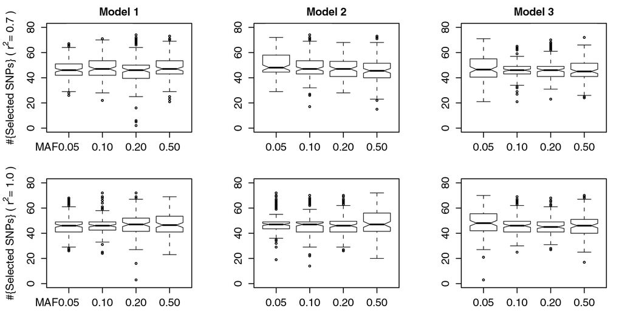

Our run

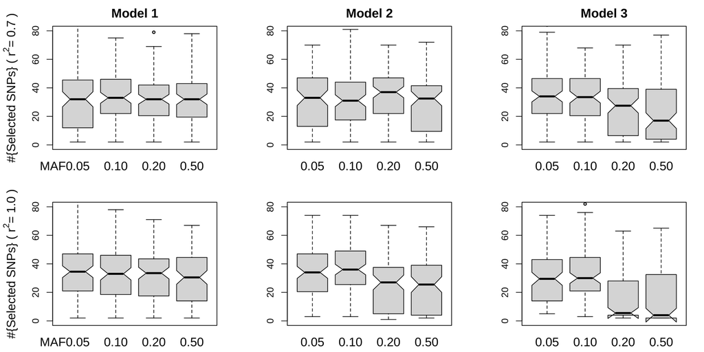

**Fig. 3, the figure (pixels)**

16.4% within 2 px, Differs

**Fig. 3, median number of SNPs SWSFS selects (24 boxes)**

0 of 24 values, Differs

The pixel score (16.4%) is no better than our boxes shifted by 2 SNPs (17.8%); the boxes sit about 14 SNPs below the paper's and are not flat across settings (fig3.medians). None of the 24 medians within error: ours run from 4 to 37 (median 32) and fall where the signal is strong, the paper's are flat at 45 to 48 in every setting. Returning the top i instead of the top i - w (i = k + 20, the number of forests built, which is how the AMD text's 84 SNPs and 104 forests relate) brings 16 of 24 within error but not the strong-signal settings (25.5 and 24 against 45 and 46). Which count the paper plotted, and with what forests, is not stated.

## Every result

Every figure, table and claim of the paper. A power or a median agrees when it is within the Monte Carlo error of two independent sets of 100 data sets (1.96 standard errors of the difference).

Result

Verdict

Measure

Why

Fig. 1, the two stages of epiForest

Not attempted

A diagram of the method; it holds no data. The method it shows is the package epiforest.

Fig. 2, power of epiForest (24 bars)

Differson review

15 of 24 values

- Model 1, r2 = 0.7, MAF 0.05: paper 0, ours **0**
- Model 1, r2 = 0.7, MAF 0.10: paper 0, ours **0**
- Model 1, r2 = 0.7, MAF 0.20: paper 0, ours **2**
- Model 1, r2 = 0.7, MAF 0.50: paper 3, ours **4**
- Model 2, r2 = 0.7, MAF 0.05: paper 0, ours **0**
- Model 2, r2 = 0.7, MAF 0.10: paper 1, ours **11**
- Model 2, r2 = 0.7, MAF 0.20: paper 13, ours **44**
- Model 2, r2 = 0.7, MAF 0.50: paper 11, ours **10**
- Model 3, r2 = 0.7, MAF 0.05: paper 0, ours **33**
- Model 3, r2 = 0.7, MAF 0.10: paper 30, ours **91**
- Model 3, r2 = 0.7, MAF 0.20: paper 83, ours **100**
- Model 3, r2 = 0.7, MAF 0.50: paper 38, ours **48**
- Model 1, r2 = 1.0, MAF 0.05: paper 0, ours **0**
- Model 1, r2 = 1.0, MAF 0.10: paper 1, ours **0**
- Model 1, r2 = 1.0, MAF 0.20: paper 0, ours **3**
- Model 1, r2 = 1.0, MAF 0.50: paper 12, ours **19**
- Model 2, r2 = 1.0, MAF 0.05: paper 16, ours **2**
- Model 2, r2 = 1.0, MAF 0.10: paper 57, ours **38**
- Model 2, r2 = 1.0, MAF 0.20: paper 97, ours **87**
- Model 2, r2 = 1.0, MAF 0.50: paper 40, ours **50**
- Model 3, r2 = 1.0, MAF 0.05: paper 89, ours **72**
- Model 3, r2 = 1.0, MAF 0.10: paper 100, ours **99**
- Model 3, r2 = 1.0, MAF 0.20: paper 100, ours **100**
- Model 3, r2 = 1.0, MAF 0.50: paper 93, ours **91**

15 of 24 bars within Monte Carlo error. Where the signal is weak (r2 = 0.7, models 2 and 3, MAF 0.05 to 0.2) ours is higher, as our chi-squared is in model 3; where the paper's epiForest is far ahead of chi-squared (models 2 and 3, r2 = 1, MAF 0.05 and 0.1) ours is lower: 2 against 16, 38 against 57, 87 against 97, 72 against 89. There our first forest ranks a disease marker low (model 2, MAF 0.05: the lower one at rank 800 in median), so neither SWSFS nor the B tests see it. The paper's forest settings are not given; mtry = 100 ranks the markers higher at MAF 0.1 but not at MAF 0.05.

Fig. 2, power of BEAM (24 bars)

Not attempted

BEAM 1.0 (Zhang and Liu 2007) was distributed only as a binary from the authors' Harvard page, which now answers 403; the Pasteur mirror keeps only its README, and the Wayback Machine could not be reached from this session. BEAM3 and StrBEAM are other methods. Rebuilding BEAM's MCMC was out of scope.

Fig. 2, power of stepwise logistic regression (24 bars)

Differson review

17 of 24 values

- Model 1, r2 = 0.7, MAF 0.05: paper 0, ours **0**
- Model 1, r2 = 0.7, MAF 0.10: paper 0, ours **0**
- Model 1, r2 = 0.7, MAF 0.20: paper 0, ours **2**
- Model 1, r2 = 0.7, MAF 0.50: paper 3, ours **4**
- Model 2, r2 = 0.7, MAF 0.05: paper 0, ours **0**
- Model 2, r2 = 0.7, MAF 0.10: paper 2, ours **5**
- Model 2, r2 = 0.7, MAF 0.20: paper 10, ours **22**
- Model 2, r2 = 0.7, MAF 0.50: paper 11, ours **10**
- Model 3, r2 = 0.7, MAF 0.05: paper 1, ours **72**
- Model 3, r2 = 0.7, MAF 0.10: paper 23, ours **86**
- Model 3, r2 = 0.7, MAF 0.20: paper 79, ours **99**
- Model 3, r2 = 0.7, MAF 0.50: paper 38, ours **45**
- Model 1, r2 = 1.0, MAF 0.05: paper 0, ours **0**
- Model 1, r2 = 1.0, MAF 0.10: paper 1, ours **0**
- Model 1, r2 = 1.0, MAF 0.20: paper 0, ours **3**
- Model 1, r2 = 1.0, MAF 0.50: paper 12, ours **18**
- Model 2, r2 = 1.0, MAF 0.05: paper 8, ours **26**
- Model 2, r2 = 1.0, MAF 0.10: paper 32, ours **56**
- Model 2, r2 = 1.0, MAF 0.20: paper 61, ours **62**
- Model 2, r2 = 1.0, MAF 0.50: paper 41, ours **47**
- Model 3, r2 = 1.0, MAF 0.05: paper 54, ours **100**
- Model 3, r2 = 1.0, MAF 0.10: paper 96, ours **100**
- Model 3, r2 = 1.0, MAF 0.20: paper 100, ours **100**
- Model 3, r2 = 1.0, MAF 0.50: paper 93, ours **91**

With the reading that fits best (interaction terms in stage 2, adjusted by all tests; found by search) 17 of 24 bars within Monte Carlo error. Four misses are model 3 at small MAF, where our chi-squared is above the paper's as well; the other three are model 2 (22 against 10 at r2 = 0.7, MAF 0.2; 26 against 8 and 56 against 32 at r2 = 1, MAF 0.05 and 0.1). The paper does not say which models stage 2 compares or how it is adjusted.

Fig. 2, power of the chi-squared test (24 bars)

Differson review

20 of 24 values

- Model 1, r2 = 0.7, MAF 0.05: paper 0, ours **0**
- Model 1, r2 = 0.7, MAF 0.10: paper 0, ours **0**
- Model 1, r2 = 0.7, MAF 0.20: paper 0, ours **2**
- Model 1, r2 = 0.7, MAF 0.50: paper 3, ours **4**
- Model 2, r2 = 0.7, MAF 0.05: paper 0, ours **0**
- Model 2, r2 = 0.7, MAF 0.10: paper 0, ours **2**
- Model 2, r2 = 0.7, MAF 0.20: paper 8, ours **16**
- Model 2, r2 = 0.7, MAF 0.50: paper 11, ours **10**
- Model 3, r2 = 0.7, MAF 0.05: paper 0, ours **26**
- Model 3, r2 = 0.7, MAF 0.10: paper 11, ours **72**
- Model 3, r2 = 0.7, MAF 0.20: paper 79, ours **99**
- Model 3, r2 = 0.7, MAF 0.50: paper 38, ours **44**
- Model 1, r2 = 1.0, MAF 0.05: paper 0, ours **0**
- Model 1, r2 = 1.0, MAF 0.10: paper 1, ours **0**
- Model 1, r2 = 1.0, MAF 0.20: paper 0, ours **3**
- Model 1, r2 = 1.0, MAF 0.50: paper 12, ours **18**
- Model 2, r2 = 1.0, MAF 0.05: paper 2, ours **2**
- Model 2, r2 = 1.0, MAF 0.10: paper 10, ours **10**
- Model 2, r2 = 1.0, MAF 0.20: paper 56, ours **52**
- Model 2, r2 = 1.0, MAF 0.50: paper 40, ours **46**
- Model 3, r2 = 1.0, MAF 0.05: paper 48, ours **64**
- Model 3, r2 = 1.0, MAF 0.10: paper 96, ours **95**
- Model 3, r2 = 1.0, MAF 0.20: paper 100, ours **100**
- Model 3, r2 = 1.0, MAF 0.50: paper 93, ours **91**

20 of 24 bars within Monte Carlo error; all four misses are model 3 at small MAF, where our chi-squared power is higher than the paper's (r2 = 0.7: 26, 72, 99 against 0, 11, 79 at MAF 0.05, 0.1, 0.2; r2 = 1: 64 against 48 at MAF 0.05). The exact power of our model (no simulation) gives the same values, so the gap is in how the paper simulated model 3 or the LD, which it does not state; the documented table, scale and prevalence readings leave model 3's marginal power unchanged, and reading 0.7 as r overshoots in the other direction.

Fig. 2, the figure (pixels, BEAM bars masked)

Differson review

68.6% within 2 px

The pixel score (68.6% of our ink near the paper's) is no better than our own bars shifted by 5 power points (71.5%), a shift within Monte Carlo error, so the drawing cannot settle the comparison; the bar values do (fig2.epiforest, fig2.lr, fig2.chisq). Both wrong-input controls score lower (22.6%, 49.1%).

Fig. 3, median number of SNPs SWSFS selects (24 boxes)

Differson review

0 of 24 values

- Model 1, r2 = 0.7, MAF 0.05: paper 46, ours **32**
- Model 1, r2 = 0.7, MAF 0.10: paper 47, ours **33**
- Model 1, r2 = 0.7, MAF 0.20: paper 46, ours **32**
- Model 1, r2 = 0.7, MAF 0.50: paper 47, ours **32**
- Model 2, r2 = 0.7, MAF 0.05: paper 48, ours **33**
- Model 2, r2 = 0.7, MAF 0.10: paper 47, ours **31**
- Model 2, r2 = 0.7, MAF 0.20: paper 47, ours **37**
- Model 2, r2 = 0.7, MAF 0.50: paper 45.5, ours **32.5**
- Model 3, r2 = 0.7, MAF 0.05: paper 46.5, ours **34**
- Model 3, r2 = 0.7, MAF 0.10: paper 46, ours **33.5**
- Model 3, r2 = 0.7, MAF 0.20: paper 46, ours **27.5**
- Model 3, r2 = 0.7, MAF 0.50: paper 45, ours **17**
- Model 1, r2 = 1.0, MAF 0.05: paper 46, ours **34.5**
- Model 1, r2 = 1.0, MAF 0.10: paper 46, ours **33**
- Model 1, r2 = 1.0, MAF 0.20: paper 47, ours **33.5**
- Model 1, r2 = 1.0, MAF 0.50: paper 46.5, ours **30.5**
- Model 2, r2 = 1.0, MAF 0.05: paper 47, ours **34**
- Model 2, r2 = 1.0, MAF 0.10: paper 47, ours **36**
- Model 2, r2 = 1.0, MAF 0.20: paper 46, ours **27**
- Model 2, r2 = 1.0, MAF 0.50: paper 47, ours **25.5**
- Model 3, r2 = 1.0, MAF 0.05: paper 48, ours **29.5**
- Model 3, r2 = 1.0, MAF 0.10: paper 46, ours **30**
- Model 3, r2 = 1.0, MAF 0.20: paper 45, ours **5.5**
- Model 3, r2 = 1.0, MAF 0.50: paper 46, ours **4**

None of the 24 medians within error: ours run from 4 to 37 (median 32) and fall where the signal is strong, the paper's are flat at 45 to 48 in every setting. Returning the top i instead of the top i - w (i = k + 20, the number of forests built, which is how the AMD text's 84 SNPs and 104 forests relate) brings 16 of 24 within error but not the strong-signal settings (25.5 and 24 against 45 and 46). Which count the paper plotted, and with what forests, is not stated.

Fig. 3, the figure (pixels)

Differson review

16.4% within 2 px

The pixel score (16.4%) is no better than our boxes shifted by 2 SNPs (17.8%); the boxes sit about 14 SNPs below the paper's and are not flat across settings (fig3.medians).

Text: all methods perform alike in model 1

Exact

1 of 1 values

- Every pair of epiForest, logistic regression and chi-squared within Monte Carlo error in all 8 model-1 settings: paper yes, ours **yes**

Text: in models 2 and 3 epiForest beats logistic regression and chi-squared at small MAF, where chi-squared does poorly

Partly agrees

2 of 4 values

- Model 2, r2 = 1, MAF 0.05 and 0.10: epiForest above both: paper yes, ours **no**
- Model 2, r2 = 1, MAF 0.05 and 0.10: chi-squared lowest: paper yes, ours **yes**
- Model 3, r2 = 1, MAF 0.05 and 0.10: epiForest above both: paper yes, ours **no**
- Model 3, r2 = 1, MAF 0.05 and 0.10: chi-squared lowest: paper yes, ours **yes**

Chi-squared is the lowest of the three at small MAF, as in the paper; epiForest is not above logistic regression there (model 2, r2 = 1: 2 and 38 against 26 and 56; model 3: 72 and 99 against 100 and 100), because our epiForest is below the paper's in these settings (fig2.epiforest).

Main claim: epiForest's power is comparable to, sometimes higher than, the other methods'

Partly agrees

3 of 4 values

- epiForest never below logistic regression beyond Monte Carlo error: paper yes, ours **no**
- epiForest above logistic regression beyond Monte Carlo error in some setting: paper yes, ours **yes**
- epiForest never below chi-squared beyond Monte Carlo error: paper yes, ours **yes**
- epiForest above chi-squared beyond Monte Carlo error in some setting: paper yes, ours **yes**

epiForest is never below chi-squared and is above it beyond Monte Carlo error in 5 settings, as the paper says, and above logistic regression in 2 (model 2, MAF 0.2: 44 against 22 at r2 = 0.7, 87 against 62 at r2 = 1). It is below logistic regression beyond Monte Carlo error in 4 of 24 settings (models 2 and 3 at MAF 0.05 or 0.1), where the paper has it level or above: in each of them our epiForest is below the paper's or our logistic regression above it (fig2.epiforest, fig2.lr).

Text: SWSFS selects about 45 SNPs in every setting, generally fewer than 80

Differs

0 of 2 values

- Median of the 24 box medians (about 45): paper 45, ours **32**
- Settings whose largest selection is below 80 (generally): paper 24, ours **17**

Our SWSFS selects a median of about 32 SNPs, not 45 (fig3.medians), and 17 of 24 settings have every selection below 80, not all 24. The claim that SWSFS keeps far fewer SNPs than the 100 of stepwise logistic regression holds (text.swsfs_below_eps).

Text: SWSFS keeps fewer candidates than the 100 (10%) of stepwise logistic regression

Exact

1 of 1 values

- Median number selected below 100: paper yes, ours **yes**

Text: BEAM beats logistic regression and chi-squared; epiForest and BEAM alike

Not attempted

Needs BEAM's power, which we could not compute (fig2.beam). On the paper's own figure the claim holds (text.arithmetic).

Claims about Figs 2 and 3 against the paper's own figure values

Agrees

Text: AMD data, 116,204 SNPs, 96 cases, 50 controls; 95,986 SNPs after filtering

Not attempted

The AMD genotypes (Klein et al. 2005, Affymetrix 100K, 96 cases and 50 controls) came from J. Hoh and were never deposited; the AREDS scan in dbGaP (phs000001) has controlled access, and whether it holds the same 146 people is unverified.

Fig. 4, gini importance of the AMD SNPs

Not attempted

The AMD genotypes (Klein et al. 2005, Affymetrix 100K, 96 cases and 50 controls) came from J. Hoh and were never deposited; the AREDS scan in dbGaP (phs000001) has controlled access, and whether it holds the same 146 people is unverified.

Text: largest gini importance rs380390 (2.73) and rs1329428 (2.44)

Not attempted

The AMD genotypes (Klein et al. 2005, Affymetrix 100K, 96 cases and 50 controls) came from J. Hoh and were never deposited; the AREDS scan in dbGaP (phs000001) has controlled access, and whether it holds the same 146 people is unverified.

Text: Bonferroni-corrected chi-squared p 0.0043 (rs380390) and 0.14 (rs1329428)

Not attempted

The AMD genotypes (Klein et al. 2005, Affymetrix 100K, 96 cases and 50 controls) came from J. Hoh and were never deposited; the AREDS scan in dbGaP (phs000001) has controlled access, and whether it holds the same 146 people is unverified.

Fig. 5, gini importance against the B-statistic p-value (AMD)

Not attempted

The AMD genotypes (Klein et al. 2005, Affymetrix 100K, 96 cases and 50 controls) came from J. Hoh and were never deposited; the AREDS scan in dbGaP (phs000001) has controlled access, and whether it holds the same 146 people is unverified.

Text: Pearson correlation of gini importance and p-value -0.59, p < 2.2e-16

Not attempted

The AMD genotypes (Klein et al. 2005, Affymetrix 100K, 96 cases and 50 controls) came from J. Hoh and were never deposited; the AREDS scan in dbGaP (phs000001) has controlled access, and whether it holds the same 146 people is unverified.

Fig. 6, out-of-bag error against the number of top SNPs (AMD)

Not attempted

The AMD genotypes (Klein et al. 2005, Affymetrix 100K, 96 cases and 50 controls) came from J. Hoh and were never deposited; the AREDS scan in dbGaP (phs000001) has controlled access, and whether it holds the same 146 people is unverified.

Text: minimum OOB error 8.5% at the top 84 SNPs; SWSFS builds 104 forests

Not attempted

The AMD genotypes (Klein et al. 2005, Affymetrix 100K, 96 cases and 50 controls) came from J. Hoh and were never deposited; the AREDS scan in dbGaP (phs000001) has controlled access, and whether it holds the same 146 people is unverified.

Table 1, top five two-way and three-way interactions in AMD

Not attempted

The AMD genotypes (Klein et al. 2005, Affymetrix 100K, 96 cases and 50 controls) came from J. Hoh and were never deposited; the AREDS scan in dbGaP (phs000001) has controlled access, and whether it holds the same 146 people is unverified.

Text: no interaction significant after Bonferroni; 9 and 14 SNPs more significant than rs6104678 and rs7863587

Not attempted

The AMD genotypes (Klein et al. 2005, Affymetrix 100K, 96 cases and 50 controls) came from J. Hoh and were never deposited; the AREDS scan in dbGaP (phs000001) has controlled access, and whether it holds the same 146 people is unverified.

Check: the B statistic's null distribution (our shift of the chi-squared)

Agrees

R package epiforest and its tutorial

Agrees

The main claim holds in part: epiForest is never below chi-squared and beats it where interactions matter, but in our run it falls below logistic regression in 4 of 24 settings at small MAF, where the paper has it level or ahead. The causes, in how the paper ran its forests, simulated model 3 and set up logistic regression, are open with the tested candidates recorded; the AMD study needs genotypes that were never released.

## What came back

**epiForest**

The gini ranking, SWSFS and the hierarchical B-statistic tests, as the R package epiforest, with tests and a tutorial.

**Chi-squared**

20 of 24 bars of Fig. 2 within Monte Carlo error; the four misses are model 3 at small MAF.

**epiForest's power**

15 of 24 bars of Fig. 2.

**Logistic regression**

17 of 24 bars, with the stage-2 test chosen by its match to these bars (4 of 24 with Marchini et al.'s strategy as published).

**The B statistic**

Its shift, which the paper does not write out, derived and checked on null data.

## What stayed buried

- The AMD study (Figs 4 to 6, Table 1): the genotypes were never deposited.
- BEAM, the fourth method of Fig. 2: its program is gone.
- Fig. 3: SWSFS keeps about 32 SNPs where the paper's figure shows 45 to 48 (median 46) in every setting; five readings of the stopping rule and the forests were tested.
- How the paper set up its forests, its model 3 and its stage-2 logistic regression: not stated, and no tested reading closes every gap.

The main claim holds in part: epiForest is never below chi-squared and beats it where interactions matter, but in our run it falls below logistic regression in 4 of 24 settings at small MAF, where the paper has it level or ahead. The causes, in how the paper ran its forests, simulated model 3 and set up logistic regression, are open with the tested candidates recorded; the AMD study needs genotypes that were never released.

## What we matched

How each part of the paper's method was rebuilt.

**Forest**

R randomForest 4.7-1.1, SNPs as three-level factors, 500 trees, mtry the square root of the number of SNPs; gini importance.

**SWSFS**

The paper's pseudocode, window 20, the out-of-bag error of each forest.

**B tests**

One-, two- and three-way, conditional on SNPs already reported; Bonferroni over all tests of each order.

**Data**

Marchini et al.'s three disease models (model 2 as in epiMODE), 1000 markers, 1000 cases and 1000 controls, 100 data sets per setting.

**Comparators**

The single-locus chi-squared test and stepwise logistic regression with three-way interactions.

## The session

The reproduction was done by an AI agent, Claude Code, in one session. Every prompt, reply and tool call of it is published.

**Wall clock**

34.8 h

first message to last, waits included

**Human prompts**

12

messages typed by a person

**Tool calls**

439

39 of them in subagents

**Tokens**

114.9 M

every request, subagents included

Read the session [The raw files](https://github.com/jeonglab-bcm/fossil/tree/main/PMC2648748/session)